# Lab 2: Project Management, Data Structure in R

Haohan Chen

September 7, 2018

## Homework

1. Upload to Sakai. Submit a PDF file created with Rmarkdown, with all your text and code inside. If you haven’t learned about that yet, submit a PDF of your text and an `.R` file of your code.
2. Questions?

## R Interface, Project Management

1. Working directory. Always use relative path when you refer to a file.
2. The way to make sure you start with the correct working directory: Create an R project: File –> New Project.
3. Saving `.Rdata`? Not a good idea.
4. Two types of files in R
   1. `.R`: only code
   2. `.Rmd`: code + text

## Finish the remaining Lab 1 material

Go to Lab 1 code

## Lecture review: Generating random variables

Let’s Start with Professor Malesky’s slides (Lecture 3, page 21):

> - Knowing (or assuming) the data-generating processes (DGPs) from which our variables are formed give us leverage in describing random variables and inferring relationships between them
>   - The DGPs are expectations of how the values of our random variables are distributed in the population
>   - They give rise to a number of theoretical distributions-ideal-type PDFs of our variables

Why do we need distributions? To summarize data. To simplify the complicated. I’ll demonstrate how to link distribution with data with two examples.

### A Continuous variable

Suppose we want to study a variable $x$ and we have the following data points

```
## 0.02, -0.18, -1.37, -0.6, 0.29, 0.39, -1.21, -0.36, -1.63, -0.26, 1.1, 0.76, -0.24, 0.99, 0.74, 0.09, -0.95, -0.2, 0.93, 0.48, -0.6, -2.19, -0.67, -2.12, -1.27, -0.37, -0.69, -0.87, -0.1, -0.25, -1.85, -0.08, 0.97, 0.18, -1.38, -1.44, 0.36, -1.76, -0.32, -0.65, 1.09, -0.76, -0.83, 0.83, -0.97, -0…
```

What do we do with this long list of number? What if we have 1000, 10000 or more data points? We need to summarize it in some way.

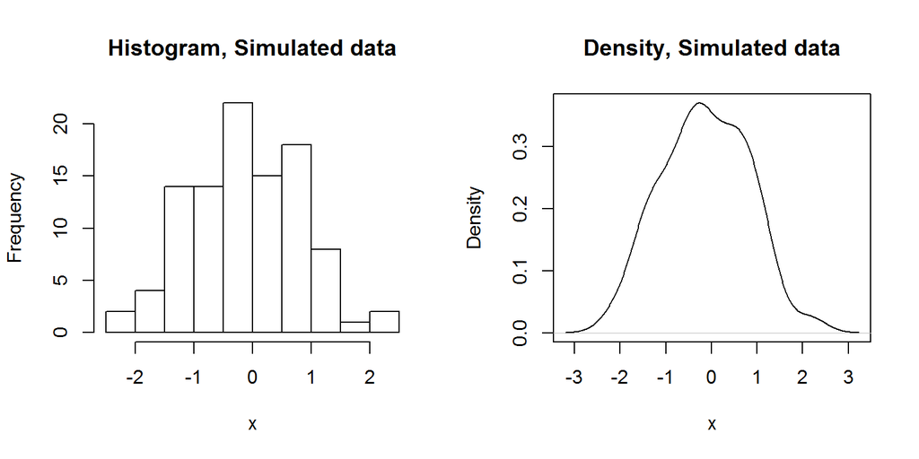

```r
par(mfrow = c(1, 2)) # Plot two graphs side by side
hist(random_num, main = "Histogram, Simulated data", xlab = "x") # Plot histogram
plot(density(random_num), main = "Density, Simulated data", xlab = "x") # Plot density
```

We also want to be able to know the *next* number we can obtain from this sequence. Upon observation, we say that the set of random number is *generated* from a normal distribution with mean 0 and variance 1. Here we make an assumption about the **Data Generating Process** as mentioned in Professor Malesky’s slide. With this assumption of data generating process, the probability density function can be specified with the following formula

$$\begin{equation*}
f(x) = \frac{1}{\sqrt{2 \pi \sigma^2}} e^{-\frac{(x - \mu)^2}{2 \sigma^2}}
\end{equation*}$$

Let’s plot ths above function and see what we get. First we define an R function of the above formula as below.

```r
# This is the PDF function that returns the density
normal_pdf <- function(x, mu, sigma){
  f <- 1 / (sqrt(2 * pi * sigma)) * exp(-(x - mu)^2 / 2 * sigma^2)
  return(f)
}
```

Then we simulate a sequence of $x$ and their corresponding density.

```r
# Simulate theoretical density of Normal distribution with mean 0, variance 1
x_sim <- seq(-4, 4, 0.1)
density_sim <- sapply(x_sim, function(x) normal_pdf(x, 0, 1))
```

Finally, we can plot the density of a Normal distribution with mean 0 and variance 1.

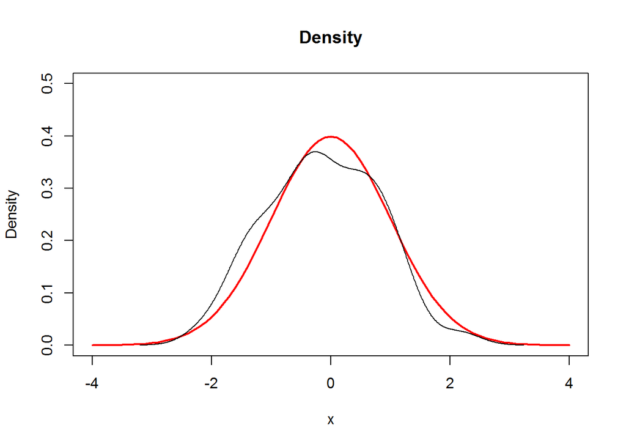

```r
# Plot density of the random number with density of N(0, 1)
plot(x_sim, density_sim, "l", col = "red", lwd = 2, main = "Density", xlab = "x", ylab = "Density", ylim = c(0, 0.5))
  # "l": plot as line; col: set color; lwd set line width, main: set title of graph
lines(density(random_num))
```

### A Discrete Variable

Now, we look at another example. Suppose we observe a variable $y$ of positive integers. It could be count of number of conflicts, number of female politicians running for office, count of protests, etc.

```
## 5, 4, 4, 6, 2, 3, 4, 4, 5, 4, 6, 5, 2, 5, 4, 4, 2, 3, 4, 7, 7, 5, 7, 4, 4, 6, 7, 3, 7, 4, 5, 2, 3, 8, 4, 6, 7, 9, 6, 5, 4, 3, 1, 6, 3, 3, 1, 5, 2, 7, 4, 9, 3, 5, 3, 5, 5, 5, 4, 5, 1, 2, 5, 4, 7, 6, 5, 5, 2, 3, 2, 5, 6, 5, 1, 5, 4, 9, 3, 3, 7, 5, 3, 6, 3, 1, 7, 4, 3, 3, 5, 6, 5, 5, 4, 7, 3, 5, 6, …
```

Again, we want to summarize this data in a concise way, especially when data is big. Also we want to infer what number can we expect to get next.

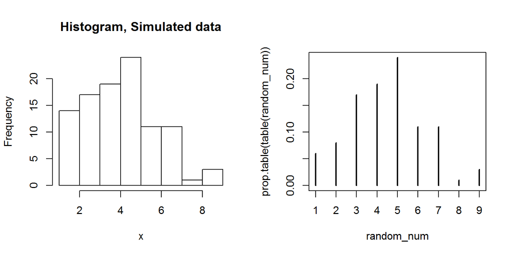

```r
par(mfrow = c(1, 2)) # Plot two graphs side by side
hist(random_num, main = "Histogram, Simulated data", xlab = "x") # Plot histogram
plot(prop.table(table(random_num))) # Proportion of each number
```

We can use a typical distribution to describe the data, the Poisson distribution. Its Probability Mass Function is
$$\begin{equation*}
f(y) = \frac{\lambda^y e^{-\lambda}}{y!}
\end{equation*}$$

Plotting this Probability Mass Function

```r
pois_pmf <- function(y, lambda){
  pmf <- (lambda^y * exp(-lambda)) / factorial(y)
  return(pmf)
}

y_sim <- 0:12
density_sim <- sapply(y_sim, function(y) pois_pmf(y, 5))
```

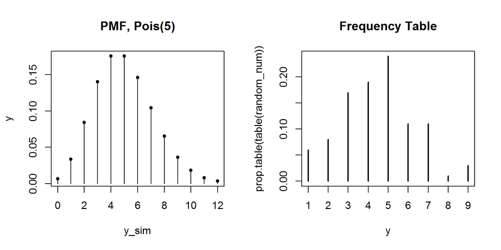

```r
par(mfrow = c(1, 2))
# Plot probability mass function
plot(y_sim, density_sim, "h", ylab = "y", main = "PMF, Pois(5)")
points(y_sim, density_sim, pch = 20)
# Plot the observed data again
plot(prop.table(table(random_num)), xlab = "y", main = "Frequency Table")
```

This is it. We use a set of ditribution to summarize our data. In our real life, we do not know the parameters (for instance, $\mu, \sigma$ of the normal distribution, $\lambda$ of the Poisson distribution). So we use various methods to estimate them. This is the major task of this course and a thousands of other statistics courses!

### Functions Generating Random Variables

Some useful functions you can use to generate random variables or get the density, probability of a random variable from a given distribution.

```r
# For normal distribution
rnorm(10, 0, 1) # Generate random numbers from a known distribution. number of random variables, mean, standard deviation
```

```
##  [1] -0.4006375 -0.3345566  1.3679540  2.1377671  0.5058193  0.7863424
##  [7] -0.9022119  0.5328970 -0.6458943  0.2909875
```

```r
qnorm(0.5, 0, 1) # Given a cumulative density of a known distribution, get the value of the variable
```

```
## [1] 0
```

```r
pnorm(0, 0, 1) # Given a random variable x, know its cumulative probability
```

```
## [1] 0.5
```

```r
# Try it with other distributions
rt; qt; pt # Student-t distribution
runif; qunif; punif # Uniform distribution
rpois; qpois; ppois # Poisson distribution
rbinom; qbinom; pbinom # Binomial distribution. Bernoulli distribution is just a special case of this
```

## R Data Structure

Material from `Advanced R`: http://adv-r.had.co.nz/Data-structures.html

### Vectors

```r
# A numeric vector
vec_num <- c(1, 2, 3)
vec_num
```

```
## [1] 1 2 3
```

```r
# A vector of strings
vec_string <- c("a", "b", "c")
vec_string
```

```
## [1] "a" "b" "c"
```

```r
# Merge vectors
vec1 <- c(2, 3, 4)
vec2 <- c(5, 4, 2)
c(vec1, vec2)
```

```
## [1] 2 3 4 5 4 2
```

```r
# Check data structure, and type of data
typeof(vec_num)
```

```
## [1] "double"
```

```r
typeof(vec_string)
```

```
## [1] "character"
```

```r
# Check if it is numeric, if it is string
is.numeric(vec_num); is.character(vec_num)
```

```
## [1] TRUE
```

```
## [1] FALSE
```

```r
is.numeric(vec_string); is.character(vec_string)
```

```
## [1] FALSE
```

```
## [1] TRUE
```

```r
# Coersion into type
vec_coerce <- c("1", "3", "7") # make a vector of characters
typeof(vec_coerce) # check type
```

```
## [1] "character"
```

```r
as.numeric(vec_coerce) # coerce into numeric
```

```
## [1] 1 3 7
```

```r
# Check length of vector
length(vec_num)
```

```
## [1] 3
```

```r
# Summarize vector
summary(vec_num)
```

```
##    Min. 1st Qu.  Median    Mean 3rd Qu.    Max.
##     1.0     1.5     2.0     2.0     2.5     3.0
```

```r
summary(vec_string)
```

```
##    Length     Class      Mode
##         3 character character
```

## Next Lab

Other data structures: List, Matrix, Dataframe